# Modeling count data

18 May 2026

## Goals for today

- Understand the application of Poisson regression to count data
- Understand how to fit Poisson regression models in **R**
- Understand how to evaluate model fits and diagnostics for Poisson regression

## Count data

Counts form the basis for much of our data in environmental sciences

- Number of adult salmon returning to spawn in a river
- Number of days of rain in a year
- Number of bees visiting a flower

## Counts vs proportions

We have seen how to model proportional data with GLMs

- \(k\) survivors out of \(n\) tagged individuals
- \(k\) infected individuals out of \(n\) susceptible individuals
- \(k\) counts of allele A in \(n\) total chromosomes

## Counts vs proportions

With count data, we only know the *frequency of occurrence*

That is, how often something occurred without knowing how often it *did not occur*

## Modeling count data

Standard regression models are inappropriate for count data for 4 reasons:

1. linear model might lead to predictions of negative counts
2. variance of the response variable may increase with the mean
3. errors are not normally distributed
4. zeros are difficult to transform

## Distribution for discrete counts

The Poisson distribution is perhaps the best known

It gives the probability of a given number of events occurring in a fixed interval of time or space

## Poisson distribution

Recall that it has one parameter \(\lambda\) to describe both the mean *and* variance

\[ y_i \sim \text{Poisson}(\lambda) \\ ~ \\ \text{Mean}(y) = \text{Var}(y) = \lambda \]

## Poisson distribution

As \(\lambda \rightarrow \infty\) the Poisson \(\rightarrow\) Normal

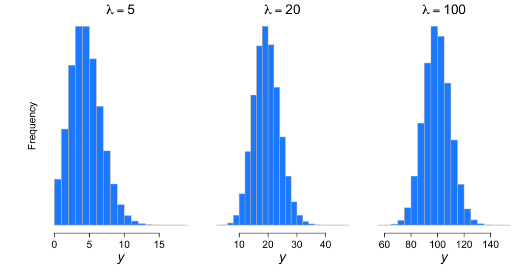

## Poisson distribution

An interesting property of the Poisson is that

\[ y_i \sim \text{Poisson}(\lambda) \\ \Downarrow \\ \sum_i y_i \sim \text{Poisson}(\sum_i \lambda_i) \]

This means we can use aggregated data if we lack individual-level data

## Poisson and binomial

The Poisson distribution can also approximate a binomial distribution if \(n\) is large and \(p\) is small

As \(p \rightarrow 0\), \(\text{logit}(p) \rightarrow \log(p)\)

Binomial with logit link \(\rightarrow\) Poisson with log link

## Poisson and binomial

An example with \(p\) = 0.05 and \(n\) = 1000

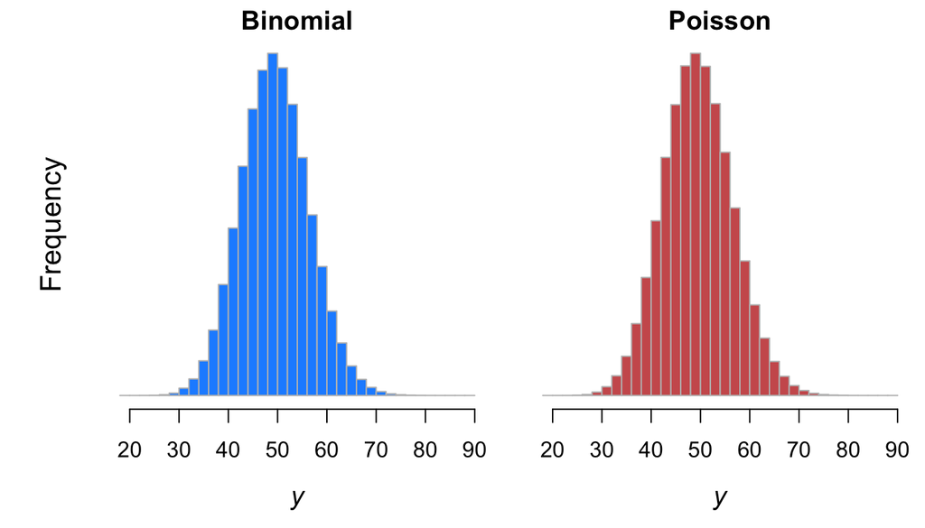

## Rethinking density

We have been considering (log) density itself as a response

\[ \text{Density}_i = f (\text{Count}_i, \text{Area}_i) \\ \Downarrow \\ \text{Density}_i = \frac{\text{Count}_i}{\text{Area}_i} \\ \]

## Rethinking density

We have been considering (log) density itself as a response

\[ \text{Density}_i = f (\text{Count}_i, \text{Area}_i) \\ \Downarrow \\ \text{Density}_i = \frac{\text{Count}_i}{\text{Area}_i} \\ \]

With GLMs, we can shift our focus to

\[ \text{Count}_i = f (\text{Area}_i) \]

## Example of a Poisson regression

Catches of prawns \(y_i\) as a function of bait type \(C_i\) and water temperature \(T_i\)

\[ \begin{aligned} \text{data distribution:} & ~~ y_i \sim \text{Poisson}(\lambda_i) \\ \\ \text{link function:} & ~~ \text{log}(\lambda_i) = \mu_i \\ \\ \text{linear predictor:} & ~~ \mu_i = \alpha + \beta_1 C_i + \beta_2 T_i \end{aligned} \]

## Catches of spot prawns

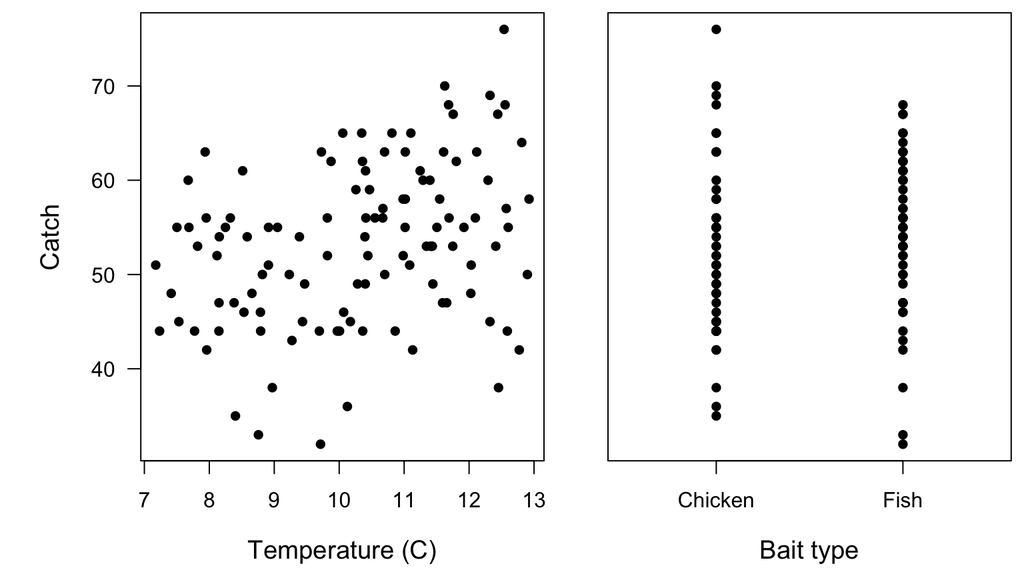

## Catches of spot prawns

```r
## Poisson regression
cmod <- glm(catch ~ fish + temp, data = prawns,
            family = poisson(link = "log"))
faraway::sumary(cmod)
```

```
##              Estimate Std. Error z value  Pr(>|z|)
## (Intercept) 3.6177725  0.0865063 41.8209 < 2.2e-16
## fish        0.0431117  0.0258818  1.6657   0.09577
## temp        0.0325383  0.0082595  3.9395 8.166e-05
##
## n = 113 p = 3
## Deviance = 134.27378 Null Deviance = 153.91684 (Difference = 19.64306)
```

## Inference from Poisson regression

We can easily estimate the CI’s on the model parameters with `confint()`

```r
## CI's for prawn model
ci_prawns <- confint(cmod)
ci_tbl <- cbind(ci_prawns[,1], coef(cmod), ci_prawns[,2])
colnames(ci_tbl) <- c("Lower", "Estimate", "Upper")
signif(ci_tbl, 3)
```

```
##                Lower Estimate  Upper
## (Intercept)  3.45000   3.6200 3.7900
## fish        -0.00763   0.0431 0.0938
## temp         0.01640   0.0325 0.0487
```

## Profile likelihood

Due to possible bias in \(\text{SE}(\beta)\), we can compute CI’s based on the *profile likelihood*

```r
## number of points to profile
nb <- 200
## possible beta's
beta_bait <- seq(0, 0.2, length = nb)
## calculate neg-LL of possible beta_bait
## fix beta_temp at its MLE
plb <- rep(NA, nb)
for(i in 1:nb) {
  mm <- glm(catch ~ 1 + offset(beta_bait[i] * fish
                               + offset(coef(cmod)[3] * temp)),
            data = prawns,
            family = poisson(link = "log"))
  plb[i] <- -logLik(mm)
}
```

## Confidence interval for \(\beta_i\)

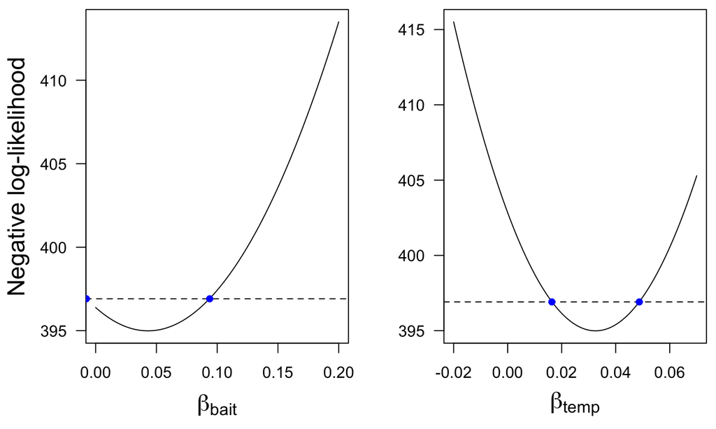

## Goodness of fit

It’s natural to ask how well a model fits the data

As with binomial models, we can check the deviance \(D\) against a \(\chi^2\) distribution

## Deviance for Poisson

Recall that the deviance for any model is

\[ D_i = \text{-}2 \left[ \log \mathcal{L}(M_i) - \log \mathcal{L}(M_S) \right] \]

where \(M_i\) is the model of interest and \(M_S\) is a *saturated* model with \(k = n\)

## Deviance for Poisson

The log-likelihood for a Poisson is

\[ \log \mathcal{L}(y; \lambda) = \sum_{i=1}^{n} \left[ y_{i} \log (\lambda_i)- \lambda_i - \log \left( y_{i}! \right) \right] \]

The deviance for a Poisson is

\[ D = 2 \sum_{i=1}^{n} \left[ y_{i} \log (y_i / \hat{\lambda}_i) - (y_i - \hat{\lambda}_i) \right] \]

## Goodness of fit for prawn model

\(H_0\): Our model is correctly specified

```r
## deviance of prawn model
D_full <- summary(cmod)$deviance
## LRT with df = 1
(p_value <- pchisq(D_full, nn - length(coef(cmod)),
                   lower.tail = FALSE))
```

```
## [1] 0.05776575
```

We cannot reject the \(H_0\)

## Goodness of fit for prawn model

It turns out that the assumption of \(D \sim \chi^2_{n - k}\) can be violated with Poisson models unless \(\lambda\) is large

Another option is Pearson’s \(X^2\) statistic we saw for binomial models

## Pearson’s goodness of fit

Recall that Pearson’s \(X^2\) is

\[ X^2 = \sum_{i = 1}^n \frac{(O_i - E_i)^2}{E_i} \sim \chi^2_{(n - k)} \\ \] So for our Poisson model

\[ X^2 = \sum_{i=1}^{n} \frac{(y_i - \hat{\lambda}_i)^2}{\hat{\lambda}_i} \sim \chi^2_{n - k} \]

## Pearson’s goodness of fit

\(H_0\): Our model is correctly specified

```r
## numerator
nm <- (prawns$catch - fitted(cmod))^2
## denominator
dm <- fitted(cmod)
## Pearson's
X2 <- sum(nm / dm)
## test
(p_value <- pchisq(X2, nn - length(coef(cmod)), lower.tail = FALSE))
```

```
## [1] 0.08262904
```

We cannot reject the \(H_0\)

## Fitted values & CI’s

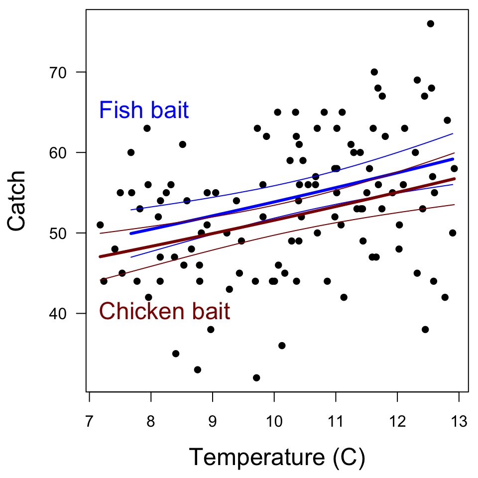

## Model diagnostics

As with other models, it’s important to examine diagnostic checks for our fitted models

## Residual plots

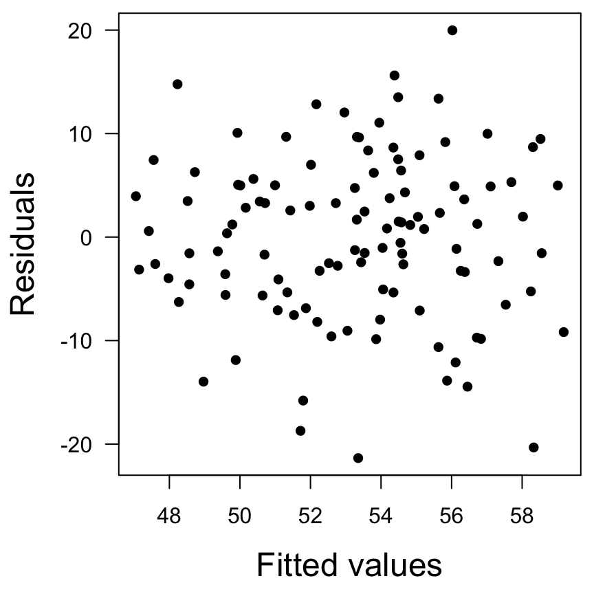

## Leverage

We can calculate the leverages \(h\) to look for unusual observation in *predictor space*

Recall we are potentially concerned about \(h > 2 \frac{k}{n}\)

We can use `faraway::halfnorm()`

## Leverage

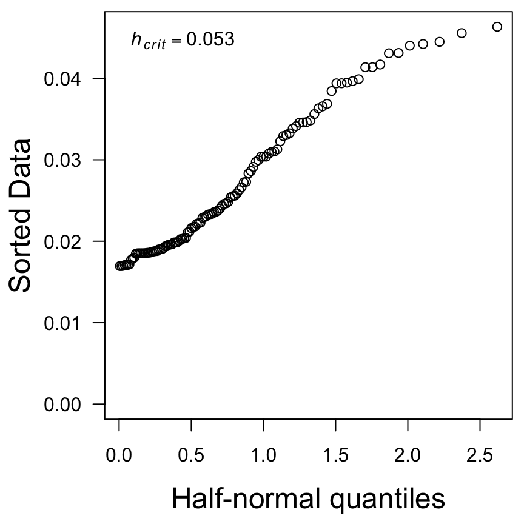

## Cook’s Distance

Recall that we can use Cook’s \(D\) to identify potentially influential points

\[ D_{i}=e_{i}^{2} \frac{1}{k}\left(\frac{h_{i}}{1-h_{i}}\right) \]

In general we are concerned about \(D_i > F^{(0.5)}_{n, n - k} \approx 1\)

## Cook’s Distance

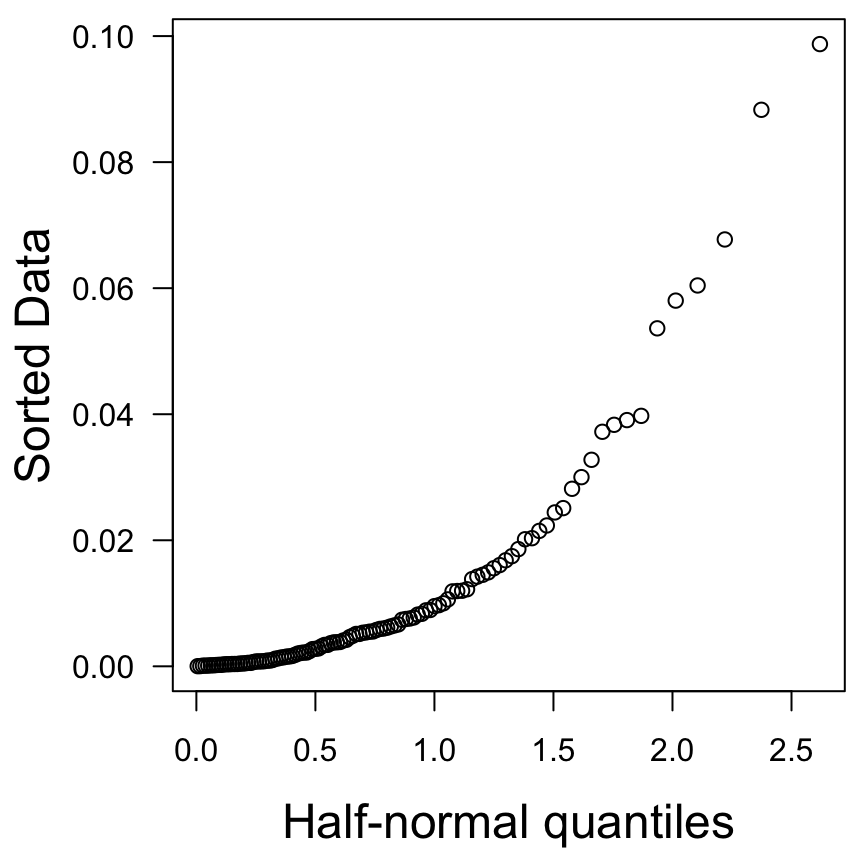

## Model selection for prawn model

We can use a likelihood ratio test to compare our model to an intercept-only model

```r
## deviance of full model
D_full <- summary(cmod)$deviance
## deviance of null model
D_null <- summary(cmod)$null.deviance
## test statistic
lambda <- D_null - D_full
## LRT with df = 2
(p_value <- pchisq(lambda, 2, lower.tail = FALSE))
```

```
## [1] 5.427058e-05
```

We reject \(H_0\) (that the data come from the null model)

## Summary

- Lots of ecological data consists of counts
- We can use Poisson regression for count data instead of a log-transformation
- We can use many of the same goodness-of-fit measures and diagnostics as for other GLMs and LMs